# Alevin-Fry Five Prime

Ally Hawkins for CCDL

This notebook compares using Alevin-fry to pre process samples captured using the 5’ kit from 10X rather than the usual 3’ approach. I am comparing Alevin-fry, using the decided upon parameters we have chosen for analyzing the 3’ libraries, to Cell Ranger for 2 5’ samples.

Alevin-fry is run using selective alignment to the splici index using the `cr-like-em` resolution for UMI deduplication. Additionally, to signify that we are aligning a 5’ library, the read orientation was switched from forward to reverse during the `generate-permit-list` step.

In contrast, Cell Ranger is able to automatically detect the library type based on how many of the reads are in the antisense direction.

Here, we are testing how well Alevin-fry using the `rc` option with 5’ library performs in comparison to using Cell Ranger’s automatic detection. To do this we will look at the distribution of UMI/cell, genes/cell, correlation of mean gene expression, and number of detected genes that overlap, similar to previous benchmarking comparisons.

## Set Up

```r
library(magrittr)
library(ggplot2)
library(SingleCellExperiment)
library(ggupset)
```

```r
# path to results files with sces and qc dataframes from running benchrmarking_generate_qc_df.R
base_dir <- here::here()
file_dir <- file.path(base_dir, "data", "five-prime-rc", "results")

# qc files
quant_info_file <- file.path(file_dir, "quant_info.tsv")
coldata_df_file <- file.path(file_dir, "coldata_qc.tsv")
rowdata_df_file <- file.path(file_dir, "rowdata_qc.tsv")

# sce objects
fry_file <- file.path(file_dir, "splici_salign_cr-like-em_sces.rds")
cellranger_file <- file.path(file_dir, "cellranger_sces.rds")

# mito file
mito_file <- file.path(base_dir, "sample-info", "Homo_sapiens.GRCh38.103.mitogenes.txt")
```

```r
# read in dataframes needed for plotting
quant_info <- readr::read_tsv(quant_info_file)
coldata_df <- readr::read_tsv(coldata_df_file)
rowdata_df <- readr::read_tsv(rowdata_df_file)
```

```r
# read in mito genes
mito_genes <- readr::read_tsv(mito_file, col_names = "gene_id")
mito_genes <- mito_genes %>%
  dplyr::pull(gene_id) %>%
  unique()
```

```r
# read in sces
fry_sce <- readr::read_rds(fry_file)
cellranger_sce <- readr::read_rds(cellranger_file)
```

```r
# merge coldata df with quant_info
coldata_info_df <- coldata_df %>%
  # rename tool to be either cellranger or alevin-fry
  dplyr::mutate(tool = ifelse(tool == "splici_salign_cr-like-em", "alevin-fry", "cellranger")) %>%
  dplyr::left_join(quant_info,
                   by = c("tool" = "tool",
                          "quant_id" = "quant_dir"))
```

## Per Cell Comparisons

### All Cells

In order to see if there are any differences between Alevin-fry and Cell Ranger in the ability to assign reads to each cell barcode, we first are looking at all cells before restricting to shared cells only.

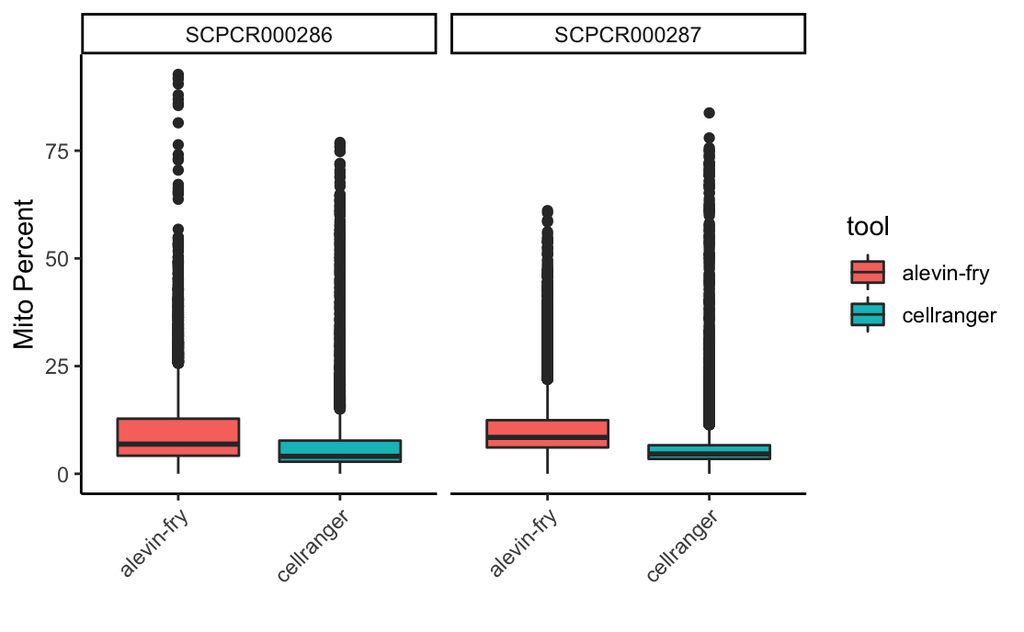

```r
# mito content in shared cells
ggplot(coldata_info_df, aes(x = tool, y = subsets_mito_percent, fill = tool)) +
  geom_boxplot() +
  facet_grid(~ sample) +
  theme_classic() +
  theme(axis.text.x = element_text(angle = 45, hjust = 1)) +
  ylab("Mito Percent") +
  xlab("")
```

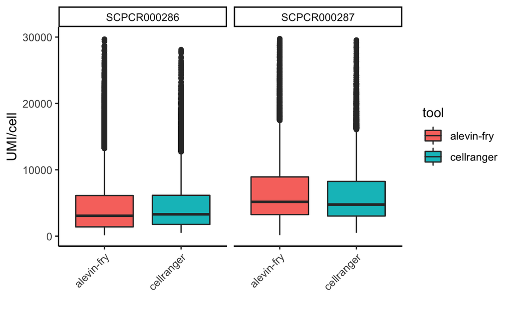

```r
ggplot(coldata_info_df, aes(x = tool, y = sum, fill = tool)) +
  geom_boxplot() +
  facet_grid(~ sample) +
  theme_classic() +
  theme(axis.text.x = element_text(angle = 45, hjust = 1)) +
  ylab("UMI/cell") +
  xlab("") +
  ylim(c(0,30000))
```

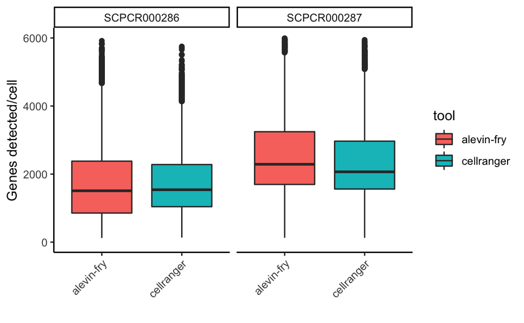

```r
ggplot(coldata_info_df, aes(x = tool, y = detected, fill = tool)) +
  geom_boxplot() +
  facet_grid(~ sample) +
  theme_classic() +
  theme(axis.text.x = element_text(angle = 45, hjust = 1)) +
  ylab("Genes detected/cell") +
  xlab("") +
  ylim(c(0,6000))
```

Here, we see that for the most part Alevin-fry and Cell Ranger are showing very similar distributions in regards to UMI/cell and genes detected/cell. It does appear that the percent mito might be slightly higher in both samples with Alevin-fry than in Cell Ranger.

### Shared Cells

We are also interested in looking at cells that are found in both tools, so we restrict our analysis to cells that are present in both.

```r
# filter for cells that are found in both alevin + cellranger
cell_counts <- coldata_info_df %>%
  dplyr::count(cell_id, sample)

common_cells <- cell_counts %>%
  dplyr::filter(n == 2) %>%
  dplyr::pull(cell_id)

coldata_qc_common <- coldata_info_df %>%
  dplyr::filter(cell_id %in% common_cells)
```

Here we are looking at the per cell metrics in just the shared cells across both alevin-fry and Cell Ranger.

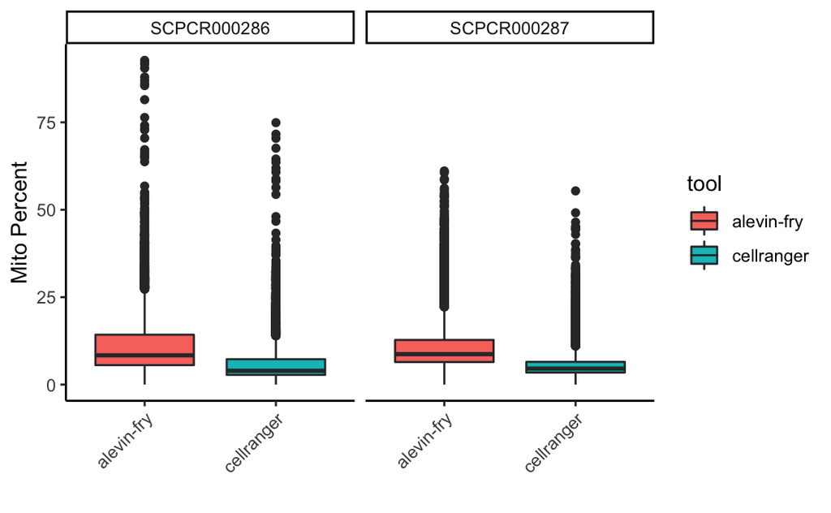

```r
# mito content in shared cells
ggplot(coldata_qc_common, aes(x = tool, y = subsets_mito_percent, fill = tool)) +
  geom_boxplot() +
  facet_grid(~ sample) +
  theme_classic() +
  theme(axis.text.x = element_text(angle = 45, hjust = 1)) +
  ylab("Mito Percent") +
  xlab("")
```

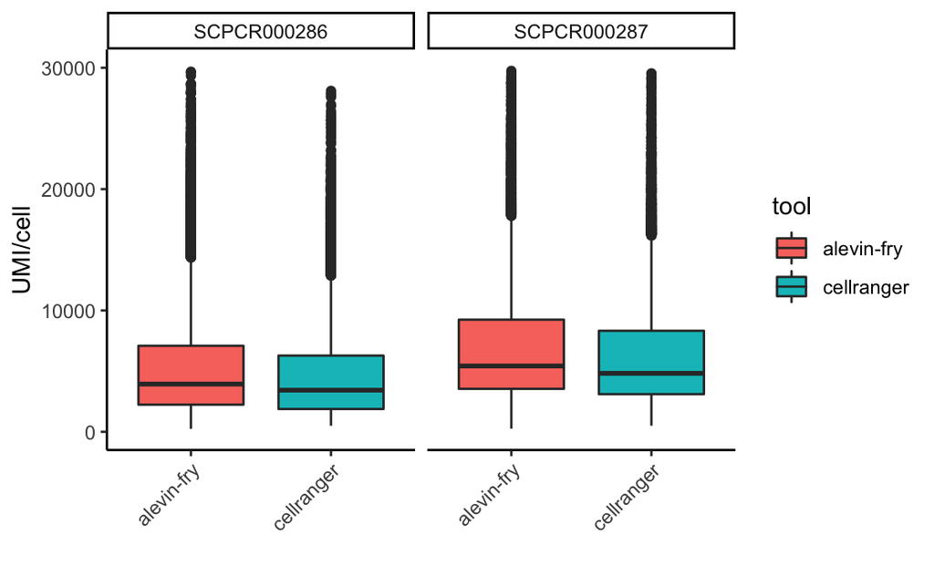

```r
ggplot(coldata_qc_common, aes(x = tool, y = sum, fill = tool)) +
  geom_boxplot() +
  facet_grid(~ sample) +
  theme_classic() +
  theme(axis.text.x = element_text(angle = 45, hjust = 1)) +
  ylab("UMI/cell") +
  xlab("") +
  ylim(c(0,30000))
```

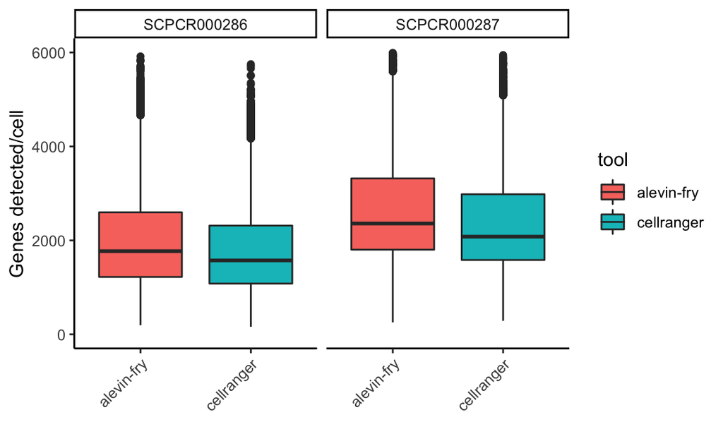

```r
ggplot(coldata_qc_common, aes(x = tool, y = detected, fill = tool)) +
  geom_boxplot() +
  facet_grid(~ sample) +
  theme_classic() +
  theme(axis.text.x = element_text(angle = 45, hjust = 1)) +
  ylab("Genes detected/cell") +
  xlab("") +
  ylim(c(0,6000))
```

Again, when restricting to shared cells, the distributions are mostly similar although it looks like Alevin-fry might be giving slightly higher counts and genes detected/cell than Cell Ranger. We can also see that the increase in mito content per cell with Alevin-fry remains higher than in Cell Ranger, even after filtering to shared cells only.

### Shared Cells, Minimum Gene Coverage

We can also restrict the comparisons to only include genes that are found in at least 5% of cells to see if low covered genes are affecting the distributions at all. To do that we will need to recalculate the per cell metrics using only genes found in > 5% of cells.

```r
# combine all tools into one list
sce_list <- append(fry_sce, cellranger_sce)

# use addPerCellQC with gene detection threshold
# only genes with detection in > 5% of cells will be included in the QC calculations
add_qc_threshold <- function(sce, mito = mito_genes, threshold = 5){
  # remove previous colData first
  colData(sce) <- NULL
  scpcaTools::add_cell_mito_qc(sce, mito = mito_genes, threshold = threshold)
}

# apply above function to all sces
sce_threshold_list <- sce_list %>%
    purrr::map(add_qc_threshold)
```

```r
# merge back into a dataframe for plotting
coldata_threshold <- sce_threshold_list %>%
  purrr::map_df(scpcaTools::coldata_to_df, .id = "quant_id") %>%
  # join with quant info to get sample and tool information
  dplyr::left_join(quant_info, by = c("quant_id" = "quant_dir"))
```

```r
# look for shared cells only
cell_counts_threshold <- coldata_threshold %>%
  dplyr::count(cell_id, sample)

common_cells_threshold <- cell_counts_threshold %>%
  dplyr::filter(n == 2) %>%
  dplyr::pull(cell_id)

qc_common_threshold <- coldata_threshold %>%
  dplyr::filter(
    (cell_id %in% common_cells_threshold)
  )
```

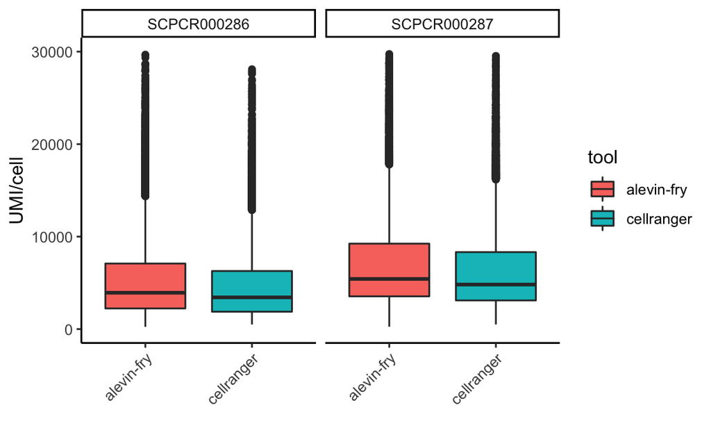

```r
ggplot(qc_common_threshold, aes(x = tool, y = sum, fill = tool)) +
  geom_boxplot() +
  facet_grid(~ sample) +
  theme_classic() +
  theme(axis.text.x = element_text(angle = 45, hjust = 1)) +
  ylab("UMI/cell") +
  xlab("") +
  ylim(c(0,30000))
```

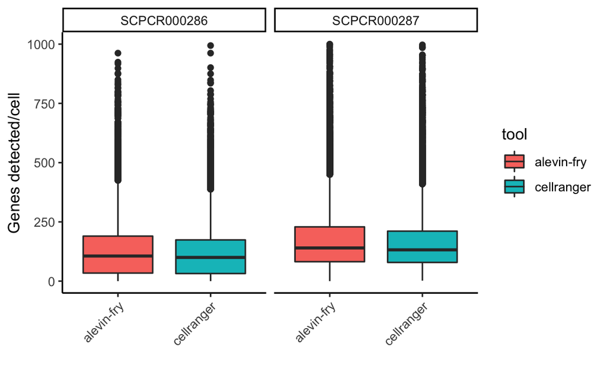

```r
ggplot(qc_common_threshold, aes(x = tool, y = detected, fill = tool)) +
  geom_boxplot() +
  facet_grid(~ sample) +
  theme_classic() +
  theme(axis.text.x = element_text(angle = 45, hjust = 1)) +
  ylab("Genes detected/cell") +
  xlab("") +
  ylim(c(0,1000))
```

It appears that restricting to highly covered genes minimizes the differences in distribution at least in genes detected/cell. As with Alevin-fry with the 3’ libraries it is possible that there are some more genes that are being detected at a lower level and when restricting to only genes found in > 5% of cells that difference decreases.

## Per Gene Comparison

Next, we will compare the mean gene expression of shared genes. Here we calculate the correlation coefficient of mean gene expression and we can plot the relationship of mean gene expression between the two tools.

```r
# combine rowdata with quant info
rowdata_info_df <- rowdata_df %>%
  dplyr::mutate(tool = dplyr::case_when(tool == "splici_salign_cr-like-em" ~ "alevin-fry",
                                        tool == "cellranger" ~ "cellranger")) %>%
  dplyr::left_join(quant_info,
                   by = c("tool" = "tool",
                          "quant_id" = "quant_dir"))


gene_counts <- rowdata_info_df %>%
  # remove genes that have a low frequency of being detected
  dplyr::filter(detected >= 5.0) %>%
  dplyr::count(gene_id, sample)

# restrict to only common genes
common_genes <- gene_counts %>%
  dplyr::filter(n == 2) %>%
  dplyr::pull(gene_id)

rowdata_qc_common <- rowdata_info_df %>%
  dplyr::filter(
    (gene_id %in% common_genes)
  )
```

```r
# spread table for comparisons
rowdata_cor <- rowdata_qc_common %>%
  dplyr::select(tool, gene_id, sample, mean) %>%
  # spread the mean expression stats to one column per caller
  tidyr::pivot_wider(id_cols = c(gene_id, sample),
                     names_from = c("tool"),
                     values_from = mean) %>%
  # drop rows with NA values to ease correlation calculation
  tidyr::drop_na()
```

```r
# calculate spearman correlation for alevin fry vs. cellranger for each sample
rowdata_cor %>%
  dplyr::group_by(sample) %>%
  dplyr::summarize(
    alevin_fry_knee_cellranger_cor = cor(`cellranger`, `alevin-fry`, method = "spearman")
  )
```

| sample | alevin_fry_knee_cellranger_cor |
| --- | --- |
| SCPCR000286 | 0.9811993 |
| SCPCR000287 | 0.9752957 |

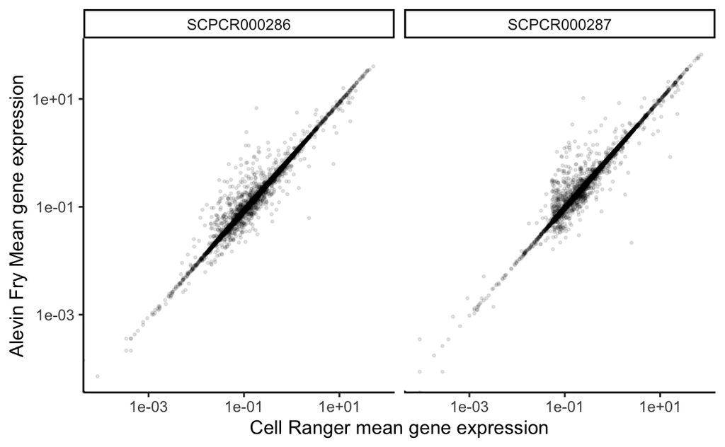

```r
ggplot(rowdata_cor, aes(x = `cellranger`, y = `alevin-fry`)) +
  geom_point(size = 0.5, alpha = 0.1) +
  facet_wrap(~ sample) +
  scale_x_log10() +
  scale_y_log10() +
  labs(x = "Cell Ranger mean gene expression", y = "Alevin Fry Mean gene expression") +
  theme_classic()
```

Similar to the 3’ libraries, the 5’ libraries have fairly high correlation between Alevin-fry and Cell Ranger.

## Overlapping Genes

In addition to looking at mean gene expression, we can also look at the actual genes that are detected in Cell Ranger and Alevin-fry and identify how much of the gene sets are overlapping or not. Because they are using different ensembl assemblies for their indices, we will need to first restrict the analysis to only genes that are able to be detected in both tools.

```r
# make a function to filter sces by subset of cells and re-calculate feature stats
filter_sce <- function(sce, cells){
  cells_to_keep <- colnames(sce) %in% cells
  SummarizedExperiment::rowData(sce) <- NULL
  sce[, cells_to_keep] %>%
    scater::addPerFeatureQC()
}
```

```r
# filter all sces together
all_sces <- list(fry_sce,
                 cellranger_sce)
names(all_sces) <- c('alevin-fry', 'cellranger')

sces_filtered <- all_sces %>%
  purrr::map(
    ~ purrr::map(.x, filter_sce, cells = common_cells)
  )

# grab rowdata from filtered sces
rowdata_filtered <- sces_filtered %>%
  purrr::map_df(
    ~ purrr::map_df(.x, scpcaTools::rowdata_to_df, .id = "quant_dir"),
    .id = "tool"
  ) %>%
  dplyr::left_join(quant_info)
```

```r
# get genes common in all tools
common_genes <- rowdata_filtered %>%
  dplyr::select(gene_id, tool) %>%
  dplyr::distinct() %>%
  dplyr::group_by(gene_id) %>%
  dplyr::tally() %>%
  # filter for genes found in both cellranger and alevin-fry
  dplyr::filter(n == 2) %>%
  dplyr::pull(gene_id)

# filter rowdata_df to only include genes found in all tools
rowdata_filtered <- rowdata_filtered %>%
  dplyr::filter(gene_id %in% common_genes)
```

Now that we have restricted to only common genes, we can then compare genes that were detected in one tool but not the other. To do this, we only want to include genes that have a mean > 0 and are detected in more than 0 cells.

```r
# filter
rowdata_filtered <- rowdata_filtered %>%
  dplyr::filter(mean > 0 & detected > 0)
```

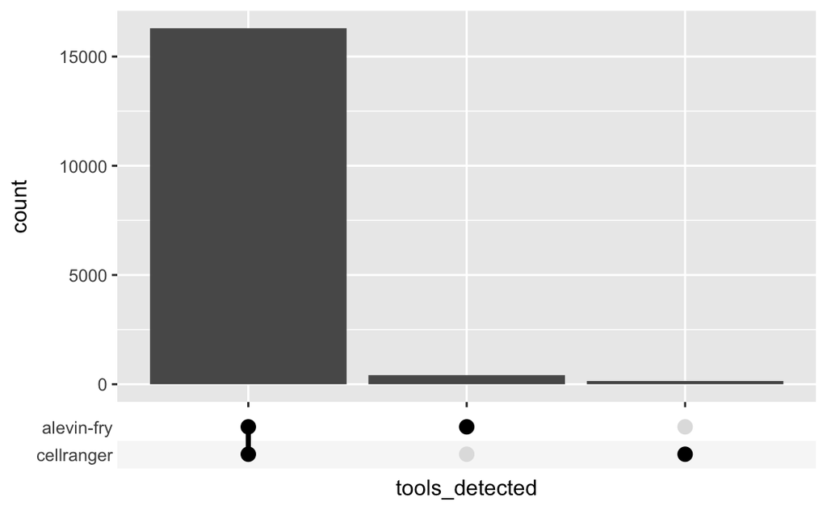

```r
gene_detect_df <- rowdata_filtered %>%
  dplyr::group_by(gene_id) %>%
  dplyr::summarise(tools_detected = list(unique(tool)))

ggplot(gene_detect_df, aes(x = tools_detected)) +
  geom_bar() +
  scale_x_upset(n_intersections = 3)
```

It appears that the number of overlapping detected genes between Alevin-fry and Cell Ranger is quite high. With the majority of genes being found in both tool, showing similar distributions of UMI and genes detected/cell, and high correlation between mean gene expression across the two tools it looks like use of the `rc` option for 5’ libraries is a good alternative to Cell Ranger.

|  | setting | value |
| --- | --- | --- |
| version | version | R version 4.0.5 (2021-03-31) |
| os | os | macOS Catalina 10.15.7 |
| system | system | x86_64, darwin17.0 |
| ui | ui | RStudio |
| language | language | (EN) |
| collate | collate | en_US.UTF-8 |
| ctype | ctype | en_US.UTF-8 |
| tz | tz | America/Chicago |
| date | date | 2021-09-20 |